# Ejecución de una API con FastAPI usando Uvicorn

Este proyecto utiliza **FastAPI** como framework para crear una API REST y **Uvicorn** como servidor ASGI para ejecutarla.

## ¿Por qué es necesario Uvicorn?

FastAPI **no es un servidor web**.  
FastAPI solo define: - Rutas (`endpoints`) - Lógica de negocio - Validación de datos

Para que la API pueda: - Escuchar peticiones HTTP - Mantener conexiones activas - Responder a clientes (navegador, Python, curl, etc.)

se necesita un **servidor ASGI**, y el más usado es **Uvicorn**.

## Forma estándar de lanzar una API con FastAPI

La forma más común, recomendada y estándar de ejecutar una aplicación FastAPI es:

```bash
uvicorn main:app --reload
```

Esta es la forma utilizada en: - Documentación oficial de FastAPI - Tutoriales profesionales - Desarrollo local - Proyectos reales

### Lanzar la interfaz grafica usando streamlit

```bash
streamlit run streamlit_app.py
```

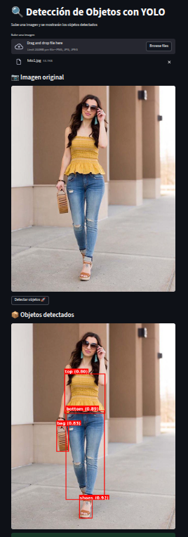

Aplicacion corriendo en streamlit que consume el API creada a aprtir del modelo yainage90/fashion-object-detection

## Explicación del comando

```bash
uvicorn main:app --reload
```

### 1. `uvicorn`

Es el servidor ASGI que ejecuta la aplicación. Se encarga de: - Recibir solicitudes HTTP - Enrutarlas a FastAPI - Enviar las respuestas al cliente

### 2. `main`

Hace referencia al archivo `main.py`.

Ejemplo:

```
main.py
```

### 3. `app`

Es el objeto FastAPI definido dentro de `main.py`.

Ejemplo:

```python
from fastapi import FastAPI

app = FastAPI()
```

### 4. `main:app`

Significa: “Usa el objeto `app` que está dentro del archivo `main.py`”

### 5. `--reload`

Activa la recarga automática. Esto significa que: - Cada vez que se guarda un cambio en el código - El servidor se reinicia automáticamente

⚠️ `--reload` solo debe usarse en desarrollo, no en producción.

## Ejemplo completo

### Estructura del proyecto:

```
project/
├── main.py
```

### Contenido de `main.py`:

```python
from fastapi import FastAPI

app = FastAPI()

@app.get("/")
def root():
    return {"status": "API funcionando"}
```

### Ejecución:

```bash
uvicorn main:app --reload
```

La API quedará disponible en: - http://127.0.0.1:8000 - http://127.0.0.1:8000/docs (Swagger UI)

## Forma estándar en producción

En producción, la forma recomendada es usar Gunicorn con workers de Uvicorn:

```bash
gunicorn main:app -k uvicorn.workers.UvicornWorker -w 4
```

Esto permite: - Manejar múltiples usuarios - Mejor rendimiento - Mayor estabilidad

## Resumen

- FastAPI define la API
- Uvicorn ejecuta la API
- `main:app` indica dónde está la aplicación
- `--reload` facilita el desarrollo
- `uvicorn main:app --reload` es la forma estándar de ejecución

## Conclusión

Usar Uvicorn no es opcional: es la manera correcta y profesional de ejecutar una aplicación FastAPI, tanto en desarrollo como en producción.